# Basics of statistical analysis in R for neurochemists

# KN7001 neurochemistry with molecular neurobiology

R is an free open-source programming language, used often for data science, statistical analysis of small or large datasets and for data visualisation.

R is free to use

R is very versatile and can be used for anything from basic ploting of a few data points, to advanced analysis of transcriptomic and genomic data. In this tutorial we will demonstrate basic usage of R for data analysis, statistics and visualisation.

The power of R lies in many packages (or libraries) that are written by the community and make our lives easier when we analyze or visualize data. In addition there is active community and many forums posts dealing with error messages exist. It’s also easy to ask on forums about a specific problem.

## Interface

Analysis in R is typically done in an IDE (Integrated Desktop Environment) - the most common for R is called RStudio https://posit.co/products/open-source/rstudio/

[figure not shown]

#### *Prerequirement: Have installed R and Rstudio on your computer*

## Example 1: Statistical analysis of neurite outgrowth

In this experiment we performed measurements of neurite outgrowth upon 2 different treatments with differentiation factors and one control in cell culture. Neurite outgrowth was measured using automated analysis pipeline and results were exported in a csv file.

We will perform data import, basic QC, visualization and statistical testing of significance.

The tutorial has instructions shown as regular text and code shown in a grey box. You can copy-paste the code from the grey box into your RStudio session. Some code blocks might require minor edits to work for you.

```r
# This is code.
# Line that starts with a "#" is called commend and is not executed as code
```

### Task 1: Import the csv file into R

In order to analyze the data it needs first to be imported and stored in computer memory (RAM). Then we can manipulate, reformat, clean, visualize the data and perform statistical analysis.

Data import from csv file is done typically using “read.csv” function. We will store the contents of the file in a object called neurites.

“<-” operator assignes the output of the function “read.csv” with parameter specifying file name to a variable “neurites”

#### First download the data from the github repository at link

Then run the following:

```r
# Then load the data into the neurites object. Fill in the correct path do your downloaded .csv file
neurites <- read.csv(file="~/Downloads/03_neurites_synthetic.csv") # Adjust the path if necessary, use <TAB> for autocompletion of paths
neurites <- read.csv(file="/Users/marek/SU drive/Teaching/2024/statistical analysis in R/Data/03_neurites_synthetic.csv")

# Hint: if you can't locate the file use function getwd() to figure out where is your local working directory
```

We can look what is now stored in “neurites” variable. Because we do not know how many lines does the file contain, we can just print the first few lines using head() funtion.

```r
head(neurites)
```

|  | control | condition_1 | condition_2 |
| --- | --- | --- | --- |
| 1 | 0.06372999 | 0.7305269 | 1.097290 |
| 2 | 0.10308265 | 1.1828578 | 3.920390 |
| 3 | 0.99902660 | 0.7414197 | 5.523907 |
| 4 | 0.60876101 | 0.6742225 | 7.151884 |
| 5 | 0.63159041 | 1.0256576 | 7.167801 |
| 6 | 0.39914599 | 1.4141315 | 7.611765 |

Another way how to investigate the data (in case it is not too big ~couple thousand lines is typically ok)

```r
View(neurites)
```

To check how many rows and columns are in this file

```r
# Prints number of rows
nrow(neurites)
```

```
## [1] 20
```

```r
# Prints number of columns
ncol(neurites)
```

```
## [1] 3
```

```r
# Prints the dimensions of the data (both rows and columns)
dim(neurites)
```

```
## [1] 20  3
```

By default the data output of ‘read.csv’ function is stored as ‘data.frame’. We can check this by doing following:

Other classes include vectors, matrix etc. We will not go much into detail regarding other classes.

```r
class(neurites)
```

```
## [1] "data.frame"
```

In addition, data can be stored in several basic data types. These include for example:

- integer (whole numbers - 1, 2, 100, 21)
- numeric (e.g. 1, 2, 4.5, 22.6 etc)
- character (strings, e.g. “a”,“dog”,“house”)
- logical (TRUE, FALSE)

What is the data type present in our data.frame ? In a data.frame, this can be different in each column. We have 3 columns in our data. In order to check this, we first need to extract the data from the columns one by one. This can be done using “$” operator.

Column names in our case are: “control”, “condition_1”, condition_2”

```r
# First check the first few items in each column
head(neurites$control)
```

```
## [1] 0.06372999 0.10308265 0.99902660 0.60876101 0.63159041 0.39914599
```

```r
# This returns a vector of values from control column
# vector is a basic data structure often used in R
```

```r
head(neurites$condition_1)
```

```
## [1] 0.7305269 1.1828578 0.7414197 0.6742225 1.0256576 1.4141315
```

```r
head(neurites$condition_2)
```

```
## [1] 1.097290 3.920390 5.523907 7.151884 7.167801 7.611765
```

```r
class(neurites$control)
```

```
## [1] "numeric"
```

```r
class(neurites$condition_1)
```

```
## [1] "numeric"
```

```r
class(neurites$condition_2)
```

```
## [1] "numeric"
```

## Task 2: Calculate descriptive statistics for our data

All three columns are numeric in our case. This means the data is continuous. Therefore we can calculate descriptive statistical parameters such as mean, quantiles or standard deviation.

We can next look at the summary of our data which prints out statistics about data distribution.

```r
summary(neurites)
```

```
##     control         condition_1      condition_2
##  Min.   :0.06373   Min.   :0.4107   Min.   : 0.0855
##  1st Qu.:0.36318   1st Qu.:0.8343   1st Qu.: 1.0736
##  Median :0.48962   Median :0.9205   Median : 3.2464
##  Mean   :0.50141   Mean   :0.9314   Mean   : 3.7242
##  3rd Qu.:0.67626   3rd Qu.:1.0401   3rd Qu.: 5.9717
##  Max.   :0.99903   Max.   :1.4141   Max.   :11.1079
```

we can calculate the mean, standard deviation, quantiles and median for control

```r
# We use $ sign to select a single column -> returns a vector of values
neurites$control
```

```
##  [1] 0.06372999 0.10308265 0.99902660 0.60876101 0.63159041 0.39914599
##  [7] 0.70256457 0.10291603 0.73953168 0.32652134 0.75598748 0.37540024
## [13] 0.50765997 0.66749165 0.54694033 0.40000315 0.96263523 0.23041589
## [19] 0.43328637 0.47157436
```

```r
mean(neurites$control)
```

```
## [1] 0.5014132
```

```r
sd(neurites$control)
```

```
## [1] 0.2651407
```

```r
quantile(neurites$control,0.25)
```

```
##       25%
## 0.3631805
```

```r
quantile(neurites$control,0.75)
```

```
##       75%
## 0.6762599
```

```r
median(neurites$control)
```

```
## [1] 0.4896172
```

We can ask how many observations in control are lower or higher than mean or quantile ?

```r
# Compare control observations with the mean of all controls
neurites$control > mean(neurites$control)
```

```
##  [1] FALSE FALSE  TRUE  TRUE  TRUE FALSE  TRUE FALSE  TRUE FALSE  TRUE FALSE
## [13]  TRUE  TRUE  TRUE FALSE  TRUE FALSE FALSE FALSE
```

```r
# Function table counts how many times do we have each categorical variable in our vector
table(c('a','a','a','a','b','b','c','c','c'))
```

```
##
## a b c
## 4 2 3
```

```r
# To apply it to our comparison we do the following:
table(neurites$control > mean(neurites$control))
```

```
##
## FALSE  TRUE
##    10    10
```

```r
table(neurites$control > quantile(neurites$control,0.9))
```

```
##
## FALSE  TRUE
##    18     2
```

##### *Exercise1 : Write code that prints the mean, standard deviation and 20th and 80th quantiles for condition_1 and condition_2*

```r
'



'
```

### 2. Data visualization

We can easily visualize the mean of samples on barplot

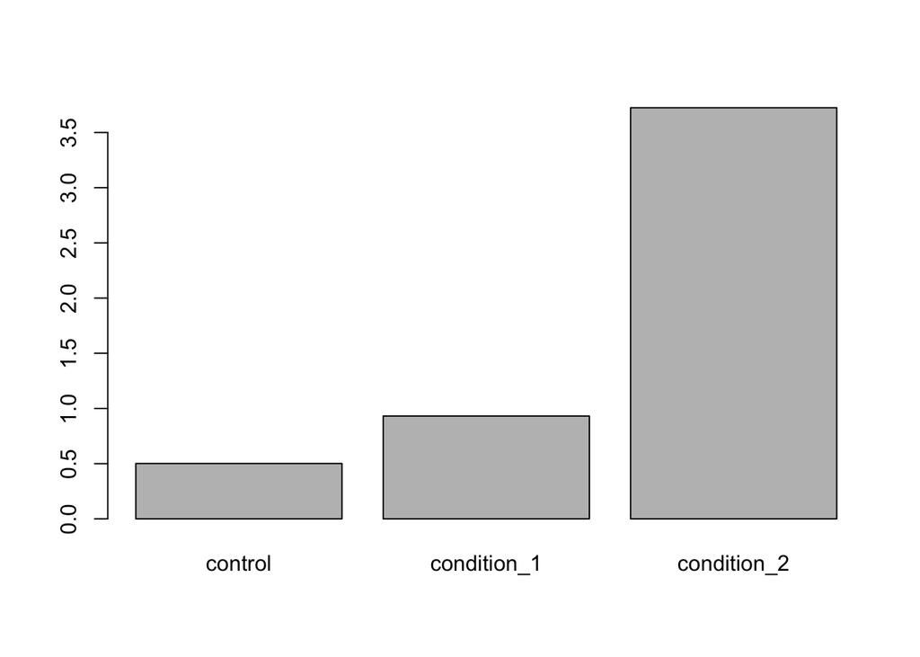

```r
# First calculate means for all 3 conditions
mean1 <- mean(neurites$control)
mean2 <- mean(neurites$condition_1)
mean3 <- mean(neurites$condition_2)

# Then plot the means using a barplot
barplot(c(mean1,mean2,mean3),names.arg = c('control','condition_1','condition_2'))
```

```r
# Note: In this command we concatenate the 3 means using function c() with 3 arguments
# Compare the following 2 commands:
# 1,2,3
# 'a','b','c'

c(1,2,3)
```

```
## [1] 1 2 3
```

```r
c('a','b','c')
```

```
## [1] "a" "b" "c"
```

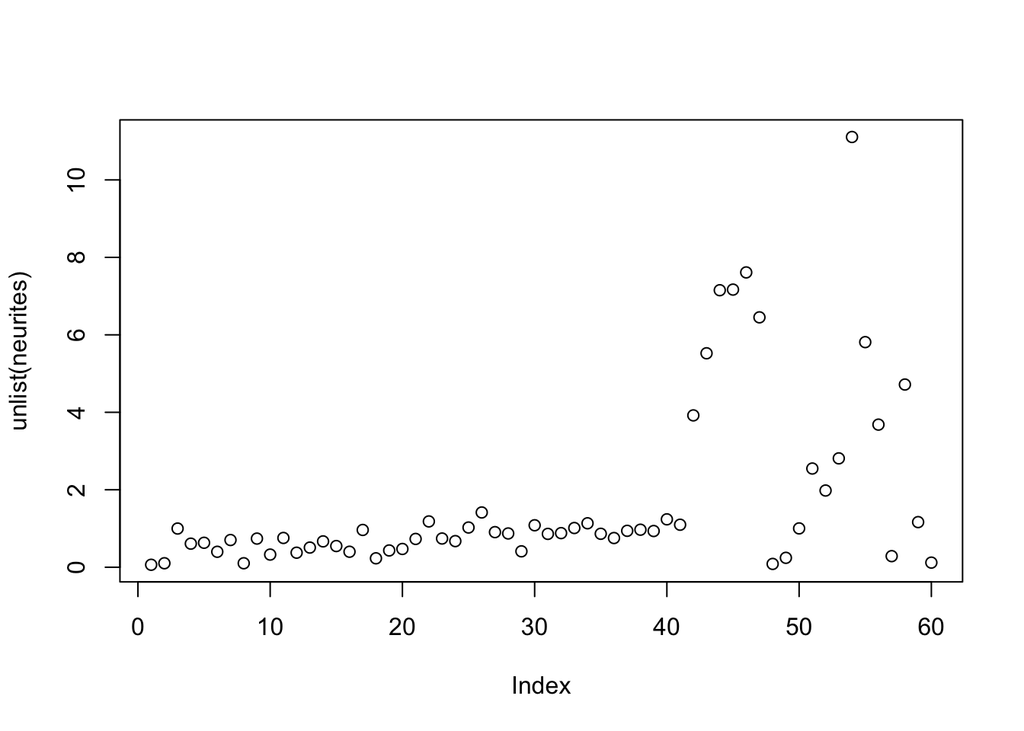

```r
# We can also plot each single observation (on the y-axis) against the index of the observation (Y-axis)

plot(unlist(neurites))
```

```r
# Note: This only works because the data is sorted in columns, if it would not be sorted/grouped the points would have random inedexes and plot would be a mess
```

Any plot can be saved into a pdf file

```r
# First open a pdf file
pdf(file = 'Neurites_plot.pdf',width=3, height=6)

# Plot into the open file
barplot(c(mean1,mean2,mean3),names.arg = c('control','condition_1','condition_2'))

# Close the file
dev.off()
```

```r
# Plot is saved in the folder below:
getwd()
```

```
## [1] "/Users/marek/SU drive/Teaching/2024/statistical analysis in R/github.io/R-teaching.github.io"
```